# Döntési Modellek a MarioKartban

Mark Fazekas

2023-05-26

# Bevezetés

Az alábbi R kód egy döntési problémát vizsgál: melyik a legjobb sofőr a MarioKart 8-ban? A játékban 43 sofőr közül választunk, amik összességében csak 16 különböző sofőr típus. A 16 csoportot fogom összehasonlítani a későbbiekben. Az adatok forrása: Kaggle (https://www.kaggle.com/datasets/marlowspringmeier/mario-kart-8-deluxe-ingame-statistics)

# Adatok betöltése

Az egyszerűség kedvéért a letöltött CSV-fájlt fogom használni, de a githubra feltöltött változatot.

```r
if (!require('readr')) install.packages('readr')
library(readr)

if (!require('utils')) install.packages('utils')
library(utils)

url <- "https://raw.githubusercontent.com/fzksmrk/dontesi-beadando/main/CSV/drivers.csv"

drivers <- read_delim(
  url,
  delim = ";",
  escape_double = FALSE,
  col_types = cols(
    Weight = col_integer(),
    Acceleration = col_integer(),
    `On-Road traction` = col_integer(),
    `Off-Road Traction` = col_integer(),
    `Mini-Turbo` = col_integer(),
    `Ground Speed` = col_integer(),
    `Water Speed` = col_integer(),
    `Anti-Gravity Speed` = col_integer(),
    `Air Speed` = col_integer(),
    `Ground Handling` = col_integer(),
    `Water Handling` = col_integer(),
    `Anti-Gravity Handling` = col_integer(),
    `Air Handling` = col_integer()
  ),
  trim_ws = TRUE
)

drivers
```

| Driver | Weight | Acceleration | On-Road traction | Off-Road Traction | Mini-Turbo | Ground Speed | Water Speed | Anti-Gravity Speed | Air Speed | Ground Handling | Water Handling | Anti-Gravity Handling | Air Handling |
| --- | --- | --- | --- | --- | --- | --- | --- | --- | --- | --- | --- | --- | --- |
| Mario | 6 | 2 | 4 | 2 | 2 | 6 | 6 | 6 | 6 | 4 | 4 | 4 | 4 |
| Luigi | 6 | 2 | 5 | 1 | 2 | 6 | 6 | 6 | 6 | 5 | 5 | 5 | 5 |
| Peach | 4 | 3 | 3 | 3 | 3 | 5 | 5 | 5 | 5 | 5 | 5 | 5 | 5 |
| Daisy | 4 | 3 | 3 | 3 | 3 | 5 | 5 | 5 | 5 | 5 | 5 | 5 | 5 |
| Yoshi | 4 | 3 | 3 | 3 | 3 | 5 | 5 | 5 | 5 | 5 | 5 | 5 | 5 |
| Toad | 3 | 4 | 3 | 4 | 3 | 3 | 3 | 3 | 3 | 7 | 7 | 7 | 7 |
| Toadette | 2 | 5 | 4 | 2 | 4 | 2 | 2 | 2 | 2 | 7 | 7 | 7 | 7 |
| Koopa Troopa | 2 | 4 | 1 | 5 | 4 | 2 | 2 | 2 | 2 | 8 | 8 | 8 | 8 |
| Bowser | 10 | 0 | 6 | 0 | 0 | 10 | 10 | 10 | 10 | 0 | 0 | 0 | 0 |
| Donkey Kong | 8 | 1 | 10 | 0 | 1 | 9 | 9 | 9 | 9 | 2 | 2 | 2 | 2 |

[output cut: 33 more lines]

# Adatok tisztítása

Oszlopnevek javítása.

```r
if (!require("janitor")) install.packages("janitor")
library(janitor)

drivers <- clean_names(drivers)
drivers
```

| driver | weight | acceleration | on_road_traction | off_road_traction | mini_turbo | ground_speed | water_speed | anti_gravity_speed | air_speed | ground_handling | water_handling | anti_gravity_handling | air_handling |
| --- | --- | --- | --- | --- | --- | --- | --- | --- | --- | --- | --- | --- | --- |
| Mario | 6 | 2 | 4 | 2 | 2 | 6 | 6 | 6 | 6 | 4 | 4 | 4 | 4 |
| Luigi | 6 | 2 | 5 | 1 | 2 | 6 | 6 | 6 | 6 | 5 | 5 | 5 | 5 |
| Peach | 4 | 3 | 3 | 3 | 3 | 5 | 5 | 5 | 5 | 5 | 5 | 5 | 5 |
| Daisy | 4 | 3 | 3 | 3 | 3 | 5 | 5 | 5 | 5 | 5 | 5 | 5 | 5 |
| Yoshi | 4 | 3 | 3 | 3 | 3 | 5 | 5 | 5 | 5 | 5 | 5 | 5 | 5 |
| Toad | 3 | 4 | 3 | 4 | 3 | 3 | 3 | 3 | 3 | 7 | 7 | 7 | 7 |
| Toadette | 2 | 5 | 4 | 2 | 4 | 2 | 2 | 2 | 2 | 7 | 7 | 7 | 7 |
| Koopa Troopa | 2 | 4 | 1 | 5 | 4 | 2 | 2 | 2 | 2 | 8 | 8 | 8 | 8 |
| Bowser | 10 | 0 | 6 | 0 | 0 | 10 | 10 | 10 | 10 | 0 | 0 | 0 | 0 |
| Donkey Kong | 8 | 1 | 10 | 0 | 1 | 9 | 9 | 9 | 9 | 2 | 2 | 2 | 2 |

[output cut: 33 more lines]

# Adatok vizsgálata

Nézzük meg az adatokat

```r
if (!require('inspectdf')) install.packages('inspectdf')
library(inspectdf)

inspect_types(drivers)
```

| type | cnt | pcnt | col_name |
| --- | --- | --- | --- |
| integer | 13 | 92.857143 |  |
| character | 1 | 7.142857 |  |

```r
inspect_cat(drivers)
```

| col_name | cnt | common | common_pcnt | levels |
| --- | --- | --- | --- | --- |
| driver | 43 | Baby Daisy | 2.325581 |  |

```r
inspect_na(drivers)
```

| col_name | cnt | pcnt |
| --- | --- | --- |
| driver | 0 | 0 |
| weight | 0 | 0 |
| acceleration | 0 | 0 |
| on_road_traction | 0 | 0 |
| off_road_traction | 0 | 0 |
| mini_turbo | 0 | 0 |
| ground_speed | 0 | 0 |
| water_speed | 0 | 0 |
| anti_gravity_speed | 0 | 0 |
| air_speed | 0 | 0 |

[output cut: 4 more lines]

```r
inspect_num(drivers)
```

| col_name | min | q1 | median | mean | q3 | max | sd | pcnt_na | hist |
| --- | --- | --- | --- | --- | --- | --- | --- | --- | --- |
| weight | 0 | 2 | 4 | 4.720930 | 7.0 | 10 | 3.187218 | 0 |  |
| acceleration | 0 | 1 | 3 | 2.813953 | 4.0 | 5 | 1.679793 | 0 |  |
| on_road_traction | 1 | 3 | 4 | 4.767442 | 7.0 | 10 | 2.688930 | 0 |  |
| off_road_traction | 0 | 1 | 3 | 2.418605 | 3.5 | 5 | 1.561936 | 0 |  |
| mini_turbo | 0 | 2 | 3 | 2.651163 | 4.0 | 5 | 1.445580 | 0 |  |
| ground_speed | 0 | 2 | 5 | 4.837209 | 7.0 | 10 | 3.116242 | 0 |  |
| water_speed | 0 | 2 | 5 | 4.837209 | 7.0 | 10 | 3.116242 | 0 |  |
| anti_gravity_speed | 0 | 2 | 5 | 4.837209 | 7.0 | 10 | 3.116242 | 0 |  |
| air_speed | 0 | 2 | 5 | 4.837209 | 7.0 | 10 | 3.116242 | 0 |  |
| ground_handling | 0 | 3 | 5 | 5.209302 | 7.0 | 10 | 2.659736 | 0 |  |

[output cut: 3 more lines]

# Új változók létrehozása

```r
if (!require('dplyr')) install.packages('dplyr')
library(dplyr)
```

csoportosítsuk az azonos rekordokat, amik csak “névben” különböznek.

```r
drivers <- drivers %>%
  group_by_if(is.numeric) %>% #group by all numeric columns
  summarise_at(vars(-one_of(names(drivers)[is.numeric(drivers)])), paste, collapse = ", ") %>% #concatenate the text variable
  summarise_all(first) #keep the first value of numeric columns
# drivers <- drivers %>%
#   mutate(number_of_recs = str_count(driver, ",") + 1)
drivers
```

| weight | acceleration | on_road_traction | off_road_traction | mini_turbo | ground_speed | water_speed | anti_gravity_speed | air_speed | ground_handling | water_handling | anti_gravity_handling | air_handling | driver |
| --- | --- | --- | --- | --- | --- | --- | --- | --- | --- | --- | --- | --- | --- |
| 0 | 4 | 3 | 5 | 5 | 0 | 0 | 0 | 0 | 10 | 10 | 10 | 10 | Baby Peach, Baby Daisy |
| 0 | 5 | 4 | 3 | 5 | 0 | 0 | 0 | 0 | 9 | 9 | 9 | 9 | Baby Rosalina, Lemmy |
| 1 | 5 | 2 | 4 | 4 | 1 | 1 | 1 | 1 | 8 | 8 | 8 | 8 | Baby Mario, Baby Luigi, Dry Bones |
| 2 | 4 | 1 | 5 | 4 | 2 | 2 | 2 | 2 | 8 | 8 | 8 | 8 | Koopa Troopa, Lakitu, Bowser Jr. |
| 2 | 5 | 4 | 2 | 4 | 2 | 2 | 2 | 2 | 7 | 7 | 7 | 7 | Toadette, Wendy, Isabelle |
| 3 | 4 | 2 | 3 | 3 | 4 | 4 | 4 | 4 | 6 | 6 | 6 | 6 | Cat Peach, Villager (female), Inkling Girl |
| 3 | 4 | 3 | 4 | 3 | 3 | 3 | 3 | 3 | 7 | 7 | 7 | 7 | Toad, Shy Guy, Larry |
| 4 | 3 | 3 | 3 | 3 | 5 | 5 | 5 | 5 | 5 | 5 | 5 | 5 | Peach, Daisy, Yoshi |
| 5 | 3 | 7 | 1 | 3 | 5 | 5 | 5 | 5 | 5 | 5 | 5 | 5 | Tanooki Mario, Villager (male), Inkling Boy |
| 6 | 2 | 4 | 2 | 2 | 6 | 6 | 6 | 6 | 4 | 4 | 4 | 4 | Mario, Ludwig, Mii (medium) |

[output cut: 6 more lines]

Számítsunk új adatokat, az egyszerűség végett. A traction, mint tapadás (magasabb érték jobb). 70%-ban on_road és 30%-ban off_road pályákról beszélünk, ezért a számított tapadás ezek az adatok súlyzott átlaga. A sebesség a különböző felületeken (szintén magasabb érték jobb) hasonló módszerrel lett kiszámolva. Az irányítás is ugyan így működik.

```r
drivers$traction <- 0.70 * drivers$on_road_traction + 0.30 * drivers$off_road_traction

drivers$speed <- 0.50 * drivers$ground_speed + 0.30 * drivers$water_speed + 0.10 * drivers$anti_gravity_speed + 0.10 * drivers$air_speed

drivers$handling <- 0.50 * drivers$ground_handling + 0.30 * drivers$water_handling + 0.10 * drivers$anti_gravity_handling + 0.10 * drivers$air_handling

drivers
```

| weight | acceleration | on_road_traction | off_road_traction | mini_turbo | ground_speed | water_speed | anti_gravity_speed | air_speed | ground_handling | water_handling | anti_gravity_handling | air_handling | driver | traction | speed | handling |
| --- | --- | --- | --- | --- | --- | --- | --- | --- | --- | --- | --- | --- | --- | --- | --- | --- |
| 0 | 4 | 3 | 5 | 5 | 0 | 0 | 0 | 0 | 10 | 10 | 10 | 10 | Baby Peach, Baby Daisy | 3.6 | 0 | 10 |
| 0 | 5 | 4 | 3 | 5 | 0 | 0 | 0 | 0 | 9 | 9 | 9 | 9 | Baby Rosalina, Lemmy | 3.7 | 0 | 9 |
| 1 | 5 | 2 | 4 | 4 | 1 | 1 | 1 | 1 | 8 | 8 | 8 | 8 | Baby Mario, Baby Luigi, Dry Bones | 2.6 | 1 | 8 |
| 2 | 4 | 1 | 5 | 4 | 2 | 2 | 2 | 2 | 8 | 8 | 8 | 8 | Koopa Troopa, Lakitu, Bowser Jr. | 2.2 | 2 | 8 |
| 2 | 5 | 4 | 2 | 4 | 2 | 2 | 2 | 2 | 7 | 7 | 7 | 7 | Toadette, Wendy, Isabelle | 3.4 | 2 | 7 |
| 3 | 4 | 2 | 3 | 3 | 4 | 4 | 4 | 4 | 6 | 6 | 6 | 6 | Cat Peach, Villager (female), Inkling Girl | 2.3 | 4 | 6 |
| 3 | 4 | 3 | 4 | 3 | 3 | 3 | 3 | 3 | 7 | 7 | 7 | 7 | Toad, Shy Guy, Larry | 3.3 | 3 | 7 |
| 4 | 3 | 3 | 3 | 3 | 5 | 5 | 5 | 5 | 5 | 5 | 5 | 5 | Peach, Daisy, Yoshi | 3.0 | 5 | 5 |
| 5 | 3 | 7 | 1 | 3 | 5 | 5 | 5 | 5 | 5 | 5 | 5 | 5 | Tanooki Mario, Villager (male), Inkling Boy | 5.2 | 5 | 5 |
| 6 | 2 | 4 | 2 | 2 | 6 | 6 | 6 | 6 | 4 | 4 | 4 | 4 | Mario, Ludwig, Mii (medium) | 3.4 | 6 | 4 |

[output cut: 6 more lines]

Az egyszerűség végett a már egyszerűsített oszlopokat távolítsuk el.

```r
drivers$on_road_traction  <- NULL
drivers$off_road_traction <- NULL

drivers$ground_speed <- NULL
drivers$water_speed <- NULL
drivers$anti_gravity_speed <- NULL
drivers$air_speed <- NULL

drivers$ground_handling <- NULL
drivers$water_handling <- NULL
drivers$anti_gravity_handling <- NULL
drivers$air_handling <- NULL

drivers
```

| weight | acceleration | mini_turbo | driver | traction | speed | handling |
| --- | --- | --- | --- | --- | --- | --- |
| 0 | 4 | 5 | Baby Peach, Baby Daisy | 3.6 | 0 | 10 |
| 0 | 5 | 5 | Baby Rosalina, Lemmy | 3.7 | 0 | 9 |
| 1 | 5 | 4 | Baby Mario, Baby Luigi, Dry Bones | 2.6 | 1 | 8 |
| 2 | 4 | 4 | Koopa Troopa, Lakitu, Bowser Jr. | 2.2 | 2 | 8 |
| 2 | 5 | 4 | Toadette, Wendy, Isabelle | 3.4 | 2 | 7 |
| 3 | 4 | 3 | Cat Peach, Villager (female), Inkling Girl | 2.3 | 4 | 6 |
| 3 | 4 | 3 | Toad, Shy Guy, Larry | 3.3 | 3 | 7 |
| 4 | 3 | 3 | Peach, Daisy, Yoshi | 3.0 | 5 | 5 |
| 5 | 3 | 3 | Tanooki Mario, Villager (male), Inkling Boy | 5.2 | 5 | 5 |
| 6 | 2 | 2 | Mario, Ludwig, Mii (medium) | 3.4 | 6 | 4 |

[output cut: 6 more lines]

# Vizuális elemzés

Nézzük meg az adatokat vizuálisan.

```r
if (!require('tidyverse')) install.packages('tidyverse')
```

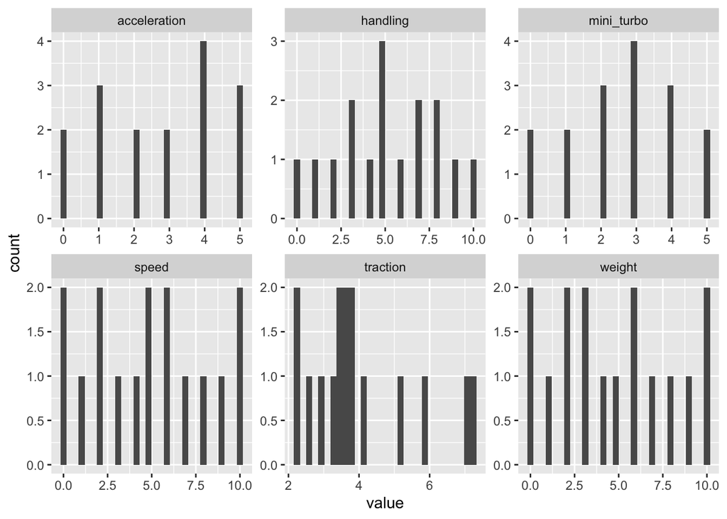

```r
library(tidyverse)

if (!require('ggplot2')) install.packages('ggplot2')
library(ggplot2)

plotdata <- drivers %>%
  select(driver,
         weight,
         acceleration,
         mini_turbo,
         traction,
         speed,
         handling) %>%
  pivot_longer(cols = c("weight", "acceleration", "mini_turbo", "traction", "speed", "handling"))


ggplot(plotdata, aes(x = value)) +
  geom_histogram() +
  facet_wrap(~ name, scales = "free")
```

Nézzük meg, hogyan korrelálnak ezek az adatok.

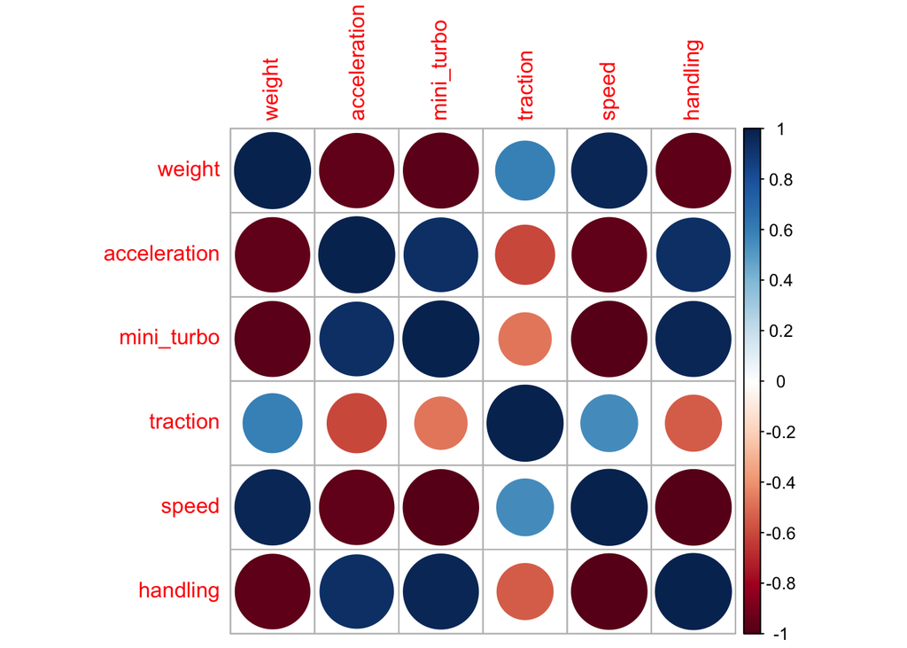

```r
if (!require('corrplot')) install.packages('corrplot')
library(corrplot)

correlation_data <- drivers %>%
  select(weight,
         acceleration,
         mini_turbo,
         traction,
         speed,
         handling)

correlation_matrix <- cor(correlation_data, use = "pairwise.complete.obs")

corrplot(correlation_matrix)
```

Vagy ezt is vizuálisabban.

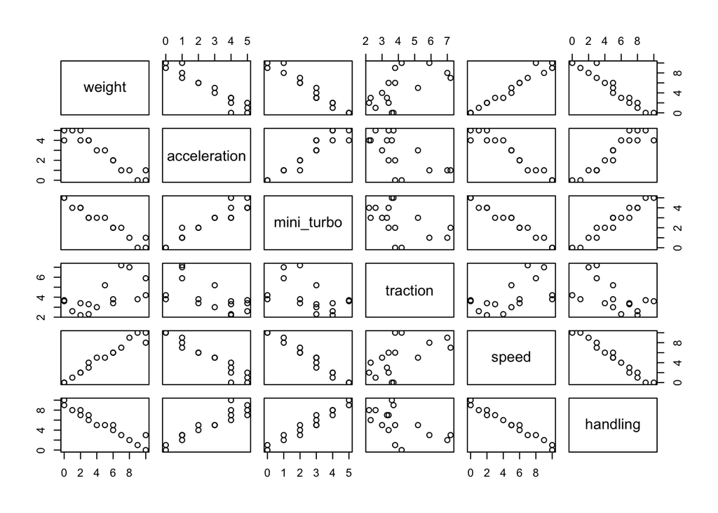

```r
# Create a new dataframe with only the quantity fields
df <- drivers[c("weight", "acceleration", "mini_turbo", "traction", "speed", "handling")]

# Create a scatterplot matrix
pairs(df)
```

Vagy még vizuálisabban.

```r
if (!require('psych')) install.packages('psych')
```

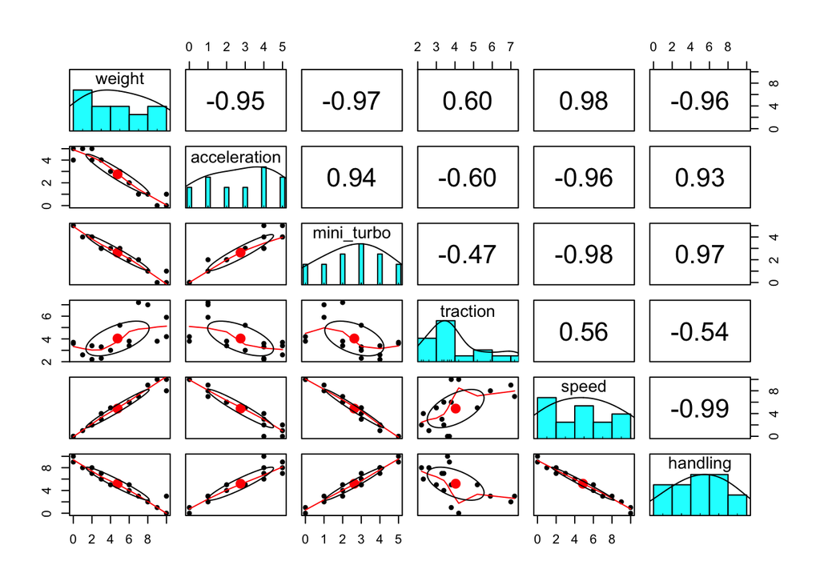

```r
library(psych)

# Create a scatterplot matrix with correlations
pairs.panels(df)
```

# Döntési modellek

## Sorrendi skála

```r
decision_1 <- drivers %>%
  ungroup() %>%
  select(driver,
         acceleration,
         mini_turbo,
         traction,
         speed,
         handling) %>%
  rownames_to_column(var = "row_name") %>%
  # mutate(id = driver) %>%
  mutate(acceleration_rank = rank(-acceleration,ties.method = "min"),
         mini_turbo_rank = rank(-mini_turbo,ties.method = "min"),
         traction_rank = rank(-traction,ties.method = "min"),
         speed_rank = rank(-speed,ties.method = "min"),
         handling_rank = rank(-handling,ties.method = "min")) %>%
  mutate(overall_rank = acceleration_rank + mini_turbo_rank + traction_rank + speed_rank + handling_rank) %>%
  mutate(overall_rank_rank = rank(overall_rank))

decision_1
```

| row_name | driver | acceleration | mini_turbo | traction | speed | handling | acceleration_rank | mini_turbo_rank | traction_rank | speed_rank | handling_rank | overall_rank | overall_rank_rank |
| --- | --- | --- | --- | --- | --- | --- | --- | --- | --- | --- | --- | --- | --- |
| 1 | Baby Peach, Baby Daisy | 4 | 5 | 3.6 | 0 | 10 | 4 | 1 | 9 | 15 | 1 | 30 | 2.0 |
| 2 | Baby Rosalina, Lemmy | 5 | 5 | 3.7 | 0 | 9 | 1 | 1 | 8 | 15 | 2 | 27 | 1.0 |
| 3 | Baby Mario, Baby Luigi, Dry Bones | 5 | 4 | 2.6 | 1 | 8 | 1 | 3 | 14 | 14 | 3 | 35 | 5.0 |
| 4 | Koopa Troopa, Lakitu, Bowser Jr. | 4 | 4 | 2.2 | 2 | 8 | 4 | 3 | 16 | 12 | 3 | 38 | 6.5 |
| 5 | Toadette, Wendy, Isabelle | 5 | 4 | 3.4 | 2 | 7 | 1 | 3 | 10 | 12 | 5 | 31 | 3.0 |
| 6 | Cat Peach, Villager (female), Inkling Girl | 4 | 3 | 2.3 | 4 | 6 | 4 | 6 | 15 | 10 | 7 | 42 | 10.0 |
| 7 | Toad, Shy Guy, Larry | 4 | 3 | 3.3 | 3 | 7 | 4 | 6 | 12 | 11 | 5 | 38 | 6.5 |
| 8 | Peach, Daisy, Yoshi | 3 | 3 | 3.0 | 5 | 5 | 8 | 6 | 13 | 8 | 8 | 43 | 11.0 |
| 9 | Tanooki Mario, Villager (male), Inkling Boy | 3 | 3 | 5.2 | 5 | 5 | 8 | 6 | 4 | 8 | 8 | 34 | 4.0 |
| 10 | Mario, Ludwig, Mii (medium) | 2 | 2 | 3.4 | 6 | 4 | 10 | 10 | 10 | 6 | 11 | 47 | 14.0 |

[output cut: 6 more lines]

```r
plotdata <- decision_1 %>%
  select(driver, acceleration_rank, mini_turbo_rank, traction_rank, speed_rank, handling_rank, overall_rank_rank) %>%
  # filter(overall_rank_rank <= 10) %>%
  pivot_longer(cols = c(acceleration_rank, mini_turbo_rank, traction_rank, speed_rank, handling_rank, overall_rank_rank)) %>%
  mutate(decision_criteria = as.factor(name), .keep = "unused") %>%
  mutate(decision_criteria = fct_relevel(decision_criteria, c("acceleration_rank", "mini_turbo_rank", "traction_rank", "speed_rank", "handling_rank", "overall_rank_rank")))
```

```r
if (!require('ggrepel')) install.packages('ggrepel')
```

[figure not shown]

```r
library(ggrepel)

ggplot(plotdata, aes(x = decision_criteria, y = value, colour = driver, group = driver, label = driver)) +
  geom_point(position = position_dodge(width = 0.05)) +
  geom_line(position = position_dodge(width = 0.05)) +
  theme_bw() +
  theme(legend.position = "none", panel.grid.minor = element_blank()) +
  geom_text_repel(data = plotdata[plotdata$decision_criteria == "acceleration_rank", ],
    direction = "y",
    xlim = c(0, 1),
    min.segment.length = 0,
    max.overlaps = Inf,
    hjust = 1,
    nudge_x = -0.17,
    size = 2) +
  geom_text_repel(data = plotdata[plotdata$decision_criteria == "overall_rank_rank", ],
    direction = "y",
    xlim = c(7.5, 10),
    min.segment.length = 0,
    max.overlaps = Inf,
    hjust = 0,
    nudge_x = 0.17,
    size = 2) +
  scale_x_discrete(expand = c(0.4, 0.1, 0.4, 0.1)) +
  labs(x = NULL, y = "rank") +
  theme_bw() +
  theme(legend.position = "none", panel.grid.minor = element_blank())
```

## Arányskála

```r
norm2 <- function(x) {
  (x - min(x)) / (max(x) - min(x))
}
```

```r
decision_1 <- decision_1 %>%
  mutate(across(.cols = c(acceleration,
         mini_turbo,
         traction,
         speed,
         handling), .fns = norm2, .names = "{.col}_norm2")) %>%
  mutate(overall_norm2 = rowMeans(select(., c(acceleration_norm2, mini_turbo_norm2, traction_norm2, speed_norm2, handling_norm2))))

decision_1
```

| row_name | driver | acceleration | mini_turbo | traction | speed | handling | acceleration_rank | mini_turbo_rank | traction_rank | speed_rank | handling_rank | overall_rank | overall_rank_rank | acceleration_norm2 | mini_turbo_norm2 | traction_norm2 | speed_norm2 | handling_norm2 | overall_norm2 |
| --- | --- | --- | --- | --- | --- | --- | --- | --- | --- | --- | --- | --- | --- | --- | --- | --- | --- | --- | --- |
| 1 | Baby Peach, Baby Daisy | 4 | 5 | 3.6 | 0 | 10 | 4 | 1 | 9 | 15 | 1 | 30 | 2.0 | 0.8 | 1.0 | 0.28 | 0.0 | 1.0 | 0.616 |
| 2 | Baby Rosalina, Lemmy | 5 | 5 | 3.7 | 0 | 9 | 1 | 1 | 8 | 15 | 2 | 27 | 1.0 | 1.0 | 1.0 | 0.30 | 0.0 | 0.9 | 0.640 |
| 3 | Baby Mario, Baby Luigi, Dry Bones | 5 | 4 | 2.6 | 1 | 8 | 1 | 3 | 14 | 14 | 3 | 35 | 5.0 | 1.0 | 0.8 | 0.08 | 0.1 | 0.8 | 0.556 |
| 4 | Koopa Troopa, Lakitu, Bowser Jr. | 4 | 4 | 2.2 | 2 | 8 | 4 | 3 | 16 | 12 | 3 | 38 | 6.5 | 0.8 | 0.8 | 0.00 | 0.2 | 0.8 | 0.520 |
| 5 | Toadette, Wendy, Isabelle | 5 | 4 | 3.4 | 2 | 7 | 1 | 3 | 10 | 12 | 5 | 31 | 3.0 | 1.0 | 0.8 | 0.24 | 0.2 | 0.7 | 0.588 |
| 6 | Cat Peach, Villager (female), Inkling Girl | 4 | 3 | 2.3 | 4 | 6 | 4 | 6 | 15 | 10 | 7 | 42 | 10.0 | 0.8 | 0.6 | 0.02 | 0.4 | 0.6 | 0.484 |
| 7 | Toad, Shy Guy, Larry | 4 | 3 | 3.3 | 3 | 7 | 4 | 6 | 12 | 11 | 5 | 38 | 6.5 | 0.8 | 0.6 | 0.22 | 0.3 | 0.7 | 0.524 |
| 8 | Peach, Daisy, Yoshi | 3 | 3 | 3.0 | 5 | 5 | 8 | 6 | 13 | 8 | 8 | 43 | 11.0 | 0.6 | 0.6 | 0.16 | 0.5 | 0.5 | 0.472 |
| 9 | Tanooki Mario, Villager (male), Inkling Boy | 3 | 3 | 5.2 | 5 | 5 | 8 | 6 | 4 | 8 | 8 | 34 | 4.0 | 0.6 | 0.6 | 0.60 | 0.5 | 0.5 | 0.560 |
| 10 | Mario, Ludwig, Mii (medium) | 2 | 2 | 3.4 | 6 | 4 | 10 | 10 | 10 | 6 | 11 | 47 | 14.0 | 0.4 | 0.4 | 0.24 | 0.6 | 0.4 | 0.408 |

[output cut: 6 more lines]

```r
plotdata <- decision_1 %>%
    # filter(overall_rank_rank < 10) %>%
  select(driver, acceleration_norm2, mini_turbo_norm2,traction_norm2,speed_norm2,handling_norm2,overall_norm2) %>%
  pivot_longer(cols = c(acceleration_norm2, mini_turbo_norm2,traction_norm2,speed_norm2,handling_norm2,overall_norm2)) %>%
  mutate(decision_criteria = as.factor(name), .keep = "unused") %>%
  mutate(decision_criteria = fct_relevel(decision_criteria, c("acceleration_norm2", "mini_turbo_norm2", "traction_norm2", "speed_norm2", "handling_norm2", "overall_norm2")))
```

[figure not shown]

```r
ggplot(plotdata, aes(x = decision_criteria, y = value, colour = driver, group = driver, label = driver)) +
geom_point(position = position_dodge(width = 0.05)) +
  geom_line(position = position_dodge(width = 0.05)) +
  theme_bw() +
  theme(legend.position = "none", panel.grid.minor = element_blank()) +
  geom_text_repel(data = plotdata[plotdata$decision_criteria == "acceleration_norm2", ],
    direction = "y",
    xlim = c(0, 1),
    min.segment.length = 0,
    max.overlaps = Inf,
    hjust = 1,
    nudge_x = -0.17,
    size = 2) +
  geom_text_repel(data = plotdata[plotdata$decision_criteria == "overall_norm2", ],
    direction = "y",
    xlim = c(7.5, 10),
    min.segment.length = 0,
    max.overlaps = Inf,
    hjust = 0,
    nudge_x = 0.17,
    size = 2) +
  scale_x_discrete(expand = c(0.4, 0.1, 0.4, 0.1)) +
  labs(x = NULL, y = "rank") +
  theme_bw() +
  theme(legend.position = "none", panel.grid.minor = element_blank())
```

# Érzékenységvizsgálat a többszempontú döntési modellekre

```r
if (!require('FuzzyR')) install.packages('FuzzyR'); library('FuzzyR')
necessary_columns <- c("acceleration", "mini_turbo","traction","speed","handling")
decision_1[necessary_columns] <- sapply(decision_1[necessary_columns], as.numeric)

# minden ugyan olyan fontos
weights <- rep(1/5, 5)

# normalizálás
decision_1_normalized <- as.data.frame(lapply(decision_1[necessary_columns], function(x) x / sqrt(sum(x^2))))

# súlyzott döntési mátrix
decision_1_weighted <- as.data.frame(lapply(decision_1_normalized, function(x) x * weights))

# legjobb és legrosszabb eset
ideal_solution <- apply(decision_1_weighted, 2, max)
negative_ideal_solution <- apply(decision_1_weighted, 2, min)

# távolság
separation_from_ideal <- sqrt(rowSums((decision_1_weighted - ideal_solution)^2))
separation_from_negative_ideal <- sqrt(rowSums((decision_1_weighted - negative_ideal_solution)^2))

# relatív távolság
relative_closeness <- separation_from_negative_ideal / (separation_from_ideal + separation_from_negative_ideal)

# rangsorolás
decision_1$rank <- rank(-relative_closeness) # '-' sign is used because we want to rank in decreasing order

decision_1
```

| row_name | driver | acceleration | mini_turbo | traction | speed | handling | acceleration_rank | mini_turbo_rank | traction_rank | speed_rank | handling_rank | overall_rank | overall_rank_rank | acceleration_norm2 | mini_turbo_norm2 | traction_norm2 | speed_norm2 | handling_norm2 | overall_norm2 | rank |
| --- | --- | --- | --- | --- | --- | --- | --- | --- | --- | --- | --- | --- | --- | --- | --- | --- | --- | --- | --- | --- |
| 1 | Baby Peach, Baby Daisy | 4 | 5 | 3.6 | 0 | 10 | 4 | 1 | 9 | 15 | 1 | 30 | 2.0 | 0.8 | 1.0 | 0.28 | 0.0 | 1.0 | 0.616 | 2 |
| 2 | Baby Rosalina, Lemmy | 5 | 5 | 3.7 | 0 | 9 | 1 | 1 | 8 | 15 | 2 | 27 | 1.0 | 1.0 | 1.0 | 0.30 | 0.0 | 0.9 | 0.640 | 3 |
| 3 | Baby Mario, Baby Luigi, Dry Bones | 5 | 4 | 2.6 | 1 | 8 | 1 | 3 | 14 | 14 | 3 | 35 | 5.0 | 1.0 | 0.8 | 0.08 | 0.1 | 0.8 | 0.556 | 5 |
| 4 | Koopa Troopa, Lakitu, Bowser Jr. | 4 | 4 | 2.2 | 2 | 8 | 4 | 3 | 16 | 12 | 3 | 38 | 6.5 | 0.8 | 0.8 | 0.00 | 0.2 | 0.8 | 0.520 | 6 |
| 5 | Toadette, Wendy, Isabelle | 5 | 4 | 3.4 | 2 | 7 | 1 | 3 | 10 | 12 | 5 | 31 | 3.0 | 1.0 | 0.8 | 0.24 | 0.2 | 0.7 | 0.588 | 1 |
| 6 | Cat Peach, Villager (female), Inkling Girl | 4 | 3 | 2.3 | 4 | 6 | 4 | 6 | 15 | 10 | 7 | 42 | 10.0 | 0.8 | 0.6 | 0.02 | 0.4 | 0.6 | 0.484 | 8 |
| 7 | Toad, Shy Guy, Larry | 4 | 3 | 3.3 | 3 | 7 | 4 | 6 | 12 | 11 | 5 | 38 | 6.5 | 0.8 | 0.6 | 0.22 | 0.3 | 0.7 | 0.524 | 7 |
| 8 | Peach, Daisy, Yoshi | 3 | 3 | 3.0 | 5 | 5 | 8 | 6 | 13 | 8 | 8 | 43 | 11.0 | 0.6 | 0.6 | 0.16 | 0.5 | 0.5 | 0.472 | 10 |
| 9 | Tanooki Mario, Villager (male), Inkling Boy | 3 | 3 | 5.2 | 5 | 5 | 8 | 6 | 4 | 8 | 8 | 34 | 4.0 | 0.6 | 0.6 | 0.60 | 0.5 | 0.5 | 0.560 | 4 |
| 10 | Mario, Ludwig, Mii (medium) | 2 | 2 | 3.4 | 6 | 4 | 10 | 10 | 10 | 6 | 11 | 47 | 14.0 | 0.4 | 0.4 | 0.24 | 0.6 | 0.4 | 0.408 | 14 |

[output cut: 6 more lines]

[figure not shown]

```r
ggplot(decision_1, aes(x=reorder(driver, rank), y=relative_closeness)) +
  geom_point() +
  theme(axis.text.x = element_text(angle = 90, hjust = 1)) +
  labs(x="Driver", y="Relative Closeness", title="TOPSIS Rankings")
```